# Peer-graded Assignment:Course Project 1

## Loading and preprocessing of the data

```r
info<- read.csv("activity.csv")
s<- split(info,info$date)
```

## What is mean total number of steps taken per day

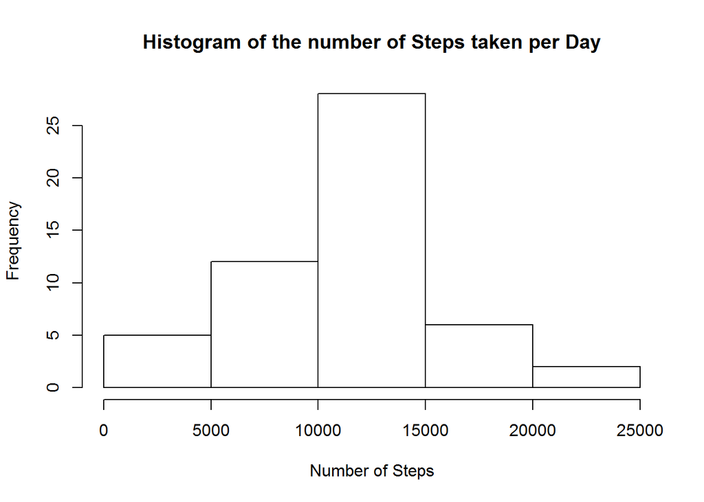

```r
nsteps<- lapply(s, function(x) sum(x$steps))
plotdata<- unlist(nsteps)
mean_of_steps <-round((mean(as.numeric(nsteps), na.rm = TRUE)), 0)
median_of_steps <- round((median(as.numeric(nsteps), na.rm = TRUE)),0)
hist(plotdata, xlab = "Number of Steps", main = "Histogram of the number of Steps taken per Day")
```

## What is the average daily activity pattern?

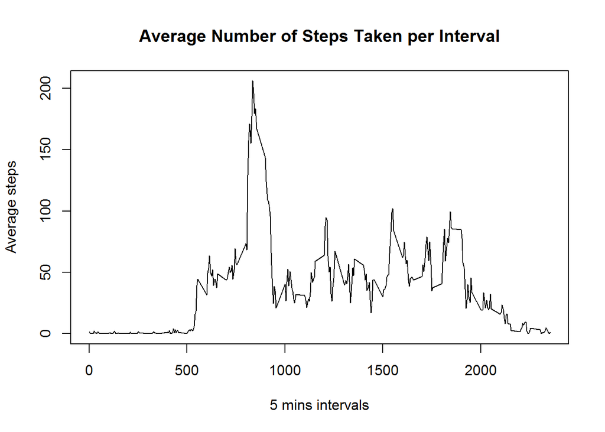

```r
times_series_data<- tapply(info$steps,info$interval,mean,na.rm= TRUE)
plot(row.names(times_series_data),times_series_data,type="l", xlab = "5 mins intervals", ylab = "Average steps", main = "Average Number of Steps Taken per Interval")
```

```r
max<- which.max(times_series_data)
interval<- names(max)
```

The interval containing the averaged maximum number of steps is 835

## Imputing Missing Values

```r
na_counts <- sum(is.na(info$steps))
```

Number of rows with missing vaue is 2304

The strategy used to fill the missing value is using the mean for that 5-minute interval.

Create a new dataset that is equal to the original dataset but with the missing data filled in.

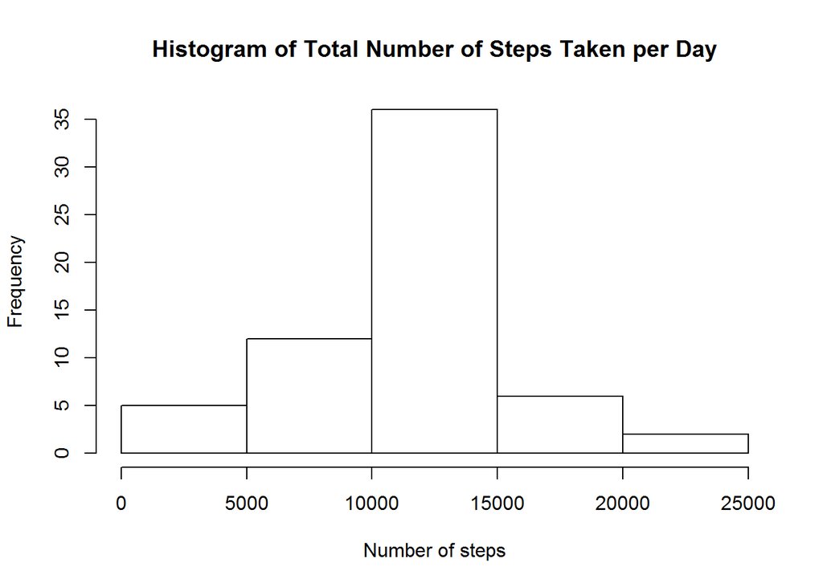

```r
new_data <- info
for(i in 1:17568){
  if(is.na(info[i,1]))
new_data[i,]$steps<-times_series_data[as.character(info[i,]$interval)]

}
s_new <- split(new_data,new_data$date)
steps<- lapply(s_new, function(x) sum(x$steps))
data<- unlist(steps)
hist(data, xlab = "Number of steps", main = "Histogram of Total Number of Steps Taken per Day")
```

```r
new_mean_of_steps <-round( mean(as.numeric(steps)),0)
new_median_of_steps <- round(median(as.numeric(steps)),0)
```

## Are there differences in activity patterns between weekdays and weekends?

Create a new factor variable in the dataset with two levels - “weekday” and “weekend” indicating whether a given date is a weekday or weekend day.

```r
new_data$day_type <- ""
days_week <- c("Montag","Dienstag","Mittwoch","Donnerstag","Freitag")

for(i in 1:17568){
  if(weekdays(as.Date(new_data[i,2])) %in% days_week){
    new_data[i,4] <- "weekday"

  }
  else{
     new_data[i,4] <- "weekend"
  }

}
new_data$day_type<- factor(new_data$day_type)
```

Make a panel plot containing a time series plot (i.e. type = “l”) of the 5-minute interval (x-axis) and the average number of steps taken, averaged across all weekday days or weekend days (y-axis).

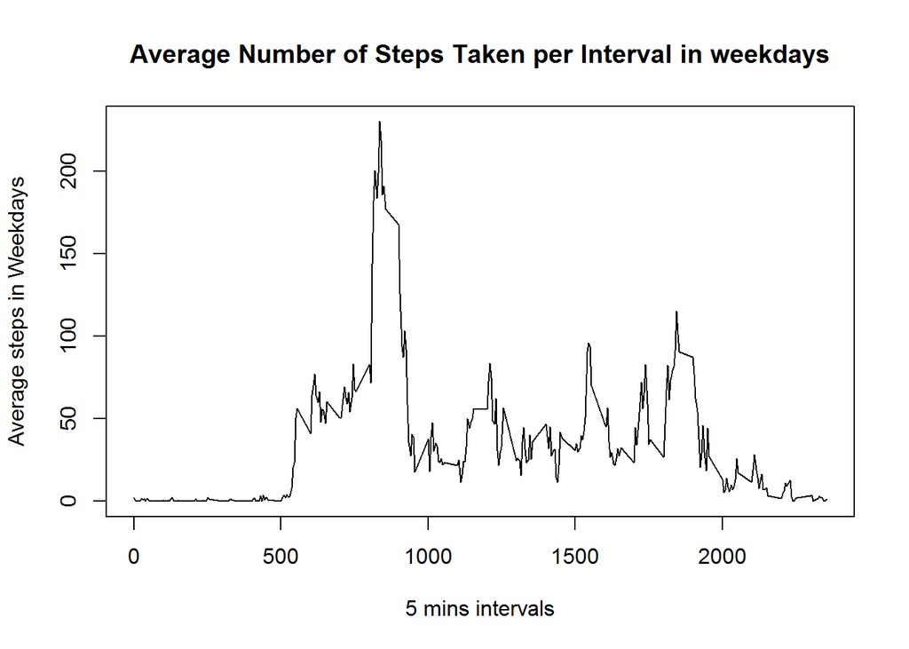

```r
temp<- split(new_data,new_data$day_type)
plot_data1<- tapply((temp$weekday)$steps,(temp$weekday)$interval,mean,na.rm= TRUE)
plot_data2<-  tapply((temp$weekend)$steps,(temp$weekend)$interval,mean,na.rm= TRUE)

plot(row.names(times_series_data),plot_data1,type="l", xlab = "5 mins intervals", ylab = "Average steps in Weekdays", main = "Average Number of Steps Taken per Interval in weekdays")
```

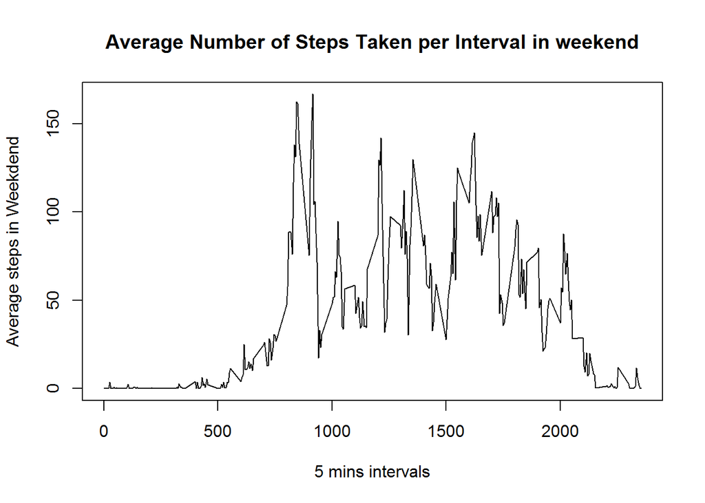

```r
plot(row.names(times_series_data),plot_data2,type="l", xlab = "5 mins intervals", ylab = "Average steps in Weekdend", main = "Average Number of Steps Taken per Interval in weekend")
```